# The relationship between Issuance & Economic Resilience

Jonas Gehrlein @ Web3 Foundation

08/10/2025

[output not shown]

# Introduction

**Disclaimer:** This text was written with minimal use of language models for editing and structuring. I apologize for any grammatical errors, but I prefer to have it less generic. All opinions expressed here are my own.

As the Polkadot network matures, ongoing discussions around issuance, staking incentives, and long-term sustainability re-emerge. There have been a few suggestions on how to further adjust Polkadot’s economic model ([Referendum 1709](https://polkadot.subsquare.io/referenda/1709), [Referendum 1710](https://polkadot.subsquare.io/referenda/1710), [Referendum 1711](https://polkadot.subsquare.io/referenda/1711)), but a central topic, namely that of economic security, has largely been ignored. This discussion, however, must be central in evaluating future policy changes, because the economic resilience is what makes or breaks Polkadot in the short- and long-term.

The recent attempt of [Qubic to attack](https://www.coindesk.com/business/2025/08/12/qubic-claims-majority-control-of-monero-hashrate-raising-51-attack-fears) economically attack Monero (XMR) illustrates that, while still in its infancy, large-scale coordinated economic attacks on consensus systems might be part of the near future.

This report addresses this topic in three parts. In the first part, it educates about economic security by conceptualizing it within Polkadot’s framework. It states necessary assumptions and illustrates what makes the network secure. We introduce the notion of a lower and upper bound of security, depending on different assumptions on the economic attack and argue that the lower bound is the key metric to evaluate any policy change.

In Part II of the report, we illustrate the impact of a drastic reduction of the issuance on the economic resilience of Polkadot. We’ll see that, due to the nature of the critical validators on the lower bound, a reduction of issuance almost proportionally weakens Polkadot’s economic resilience. In Part III of the report, we use the insights from that analysis to propose policies that aim to combine the goal of preserving (and potentially strengthening) the economic security of Polkadot, **if the community achieves consensus** to drastically reduce issuance. Together, these three sections provide a foundation for a more informed discussion around how Polkadot can evolve toward a more sustainable and secure economic design. It must be noted that crucial discussions about the **demand-side** of Polkadot, which is arguably the more important one, is out of scope for this report. Data is used from one of the most recent era (1900).

**Shout out** to Parity’s data team for providing the necessary data and infrastructure for this analysis.

# Part I: Polkadot’s Economic Resilience

Economic security in Proof-of-Stake (as well as NPoS) systems relies on staked tokens as collateral, so that any attempt to subvert consensus carries the risk of forfeiting a significant financial position. This alignment of incentives yields a probabilistic security model where the chance of a successful attack falls off exponentially as the size of the honest stake grows. In contrast, zero-knowledge (zk) systems employ succinct cryptographic proofs that, under well-studied hardness assumptions, make cheating virtually impossible and thus provide near-100% security guarantees grounded in mathematics/cryptography. However, these deterministic assurances come at a steep price: proof generation hardware for zk-coprocessors can cost on the order of 10⁶ times more than running the same computation in a cryptoeconomic setting. Gavin Wood explored the idea of transitioning to a zk-based consensus in his recent talk at the [Web3 Summit 2025](https://youtu.be/PV1QP8cJh74?si=RIHPoix1KlbxUOEb) and concluded that it might not be feasible in the short-term, but potentially in the future.

By accepting a negligible probability of failure instead of absolute certainty, PoS networks achieve robust security at a tiny fraction of the resource and cost overhead of full zk solutions and thereby striking a pragmatic balance that favors scalability and economic efficiency. Furthermore, it should be stated that the track-record of major Proof-of-Stake system is flawless when it comes to the security guarantees and we haven’t observed any major economic attack on any PoS-consensus system.

In this section, we focus on the security aspect of the staking system making different analyses around the DOT at stake. As mentioned before, the security of polkadot originates from the value of bonded tokens in the staking system. They represent the economic mass that is at stake and slashable by the protocol in the case that a misconduct of one or several validators is detected.

As a quick reminder, the Nominated Proof-of-Stake (NPoS) protocol knows two key player types: validators and nominators. The former group are actively maintaining the blockchain, running code on physical machines and provide consensus. The latter group is tasked to search and select proper validator that they deem trustworthy to do a good and honest job in maintaining the blockchain according to the rules. When it comes to stake, we can make two key distinctions. First, the **self-stake**, which is the stake that validators are nominating themselves and is, without a doubt, in the ownership of a validator. Second, the **other-stake**, which is the sum of all other nominations for that validator. Both quantities combined are the **total-stake**. If the active validators are behaving according to the protocol’s rule, they and all their nominators are rewarded with newly minted tokens. If a validator behaves incompetent or maliciously (and are caught by honest nodes), they and all their nominators are slashed.

When we analyze the economic security, it is crucial to first get an idea about what (economic) attacks are possible. Here we assume, that an attacker wants to obtain and coordinate 1/3N+1 of the nodes (to break Byzantine Fault Tolerance) to halt finality, a detrimental situation for any PoS-system. Which stake is relevant depends on the way the malicious actor coordinates the attack. In Scenario A, we assume that it is an external entity that spins up its own validators and supports them with its own stake until the critical mass to attack consensus is reached. This would certainly be the most expensive attack as they would need to get the total-stake themselves. This can, therefore, be considered the **upper bound** for the cost of an attack. Another way, Scenario B, is to bribe existing validators and form a malicious coalition (potentially coordinated by another Treasury). Here, we’d argue that the involved validators risk their self-stake and have little incentive to incorporate the other-stake into their consideration. This, therefore, can be considered the **lower bound** for the costs of an attack.

In both cases, we assume that once the attack is completed, all value of the network diminishes and can’t be revived. Therefore, validators are not only losing their respective stake but also any future rewards generated from validating and staking (their self-stake). Therefore, to make the analysis more reasonable, we can apply a concept from economics that is called **perpetual annuity**. This expresses the idea that a rational agent is indifferent between getting some payoff **now or some other payoff continuously in the future**. This assumes some discount factor which represent the opportunity costs and normally equals the risk-free rate. This rate, however, is not really meaningful in the blockchain space, so we assume a slightly higher rate, 8%, which is slightly higher than in traditional finance.

The economic resilience of a single validator is **the sum of the following metrics**:

1. **Stake**: Depending on the scenario either self-stake or total-stake
2. **Perpetual Annuity from Commission**:
   $$\left( \frac{TotalEraRewards}{{NumberValidators}}
   * CommissionPercent * NumberPayouts \right) /
   DiscountFactor$$
3. **Perpetual Annuity from Self-stake**:
   $$\left( \frac{TotalEraRewards}{{NumberValidators}}
   * (1 - CommissionPercent) * \frac{SelfStake}{{TotalStake}} *
   NumberPayouts \right) / DiscountFactor$$

Definition of metrics used:

Let’s state some additional underlying assumptions. We assume that…

- … the attacker aims to obtain 1/3N+1 of all active validators.
- … a successful attack on consensus would lead to a halt of finality and result in a catastrophic market reaction (value -> 0). Validators would never have the ability to validate again, lose all their stake and all future payouts.
- … two different scenarios with regard to the stake necessary to attack. In the first (upper bound), we assume that validators care about losing their total-stake and all future rewards and in the second (lower bound), we assume that validators only care about their self-stake and all future rewards.
- … validators that are running on 100% commission or block nominations either have direct ownership of the total-stake (self-nominating) or are bound by legal contracts and hold funds in custody. Therefore, for both attack scenarios, we assume that the self-stake is equal to the total stake for these validators.
- … reputation has no economic value. This is obviously not true, but reputation is almost impossible to quantify and can be regarded as an omitted variable that affects all scenarios equally.

### Scenario A: Upper Bound

The following graph sorts the validators based on the sum of their total stake and the perpetual annuity of the future rewards from lowest to highest. Then, we sum those two metrics to gain the economic resilience in that scenario (in DOT).

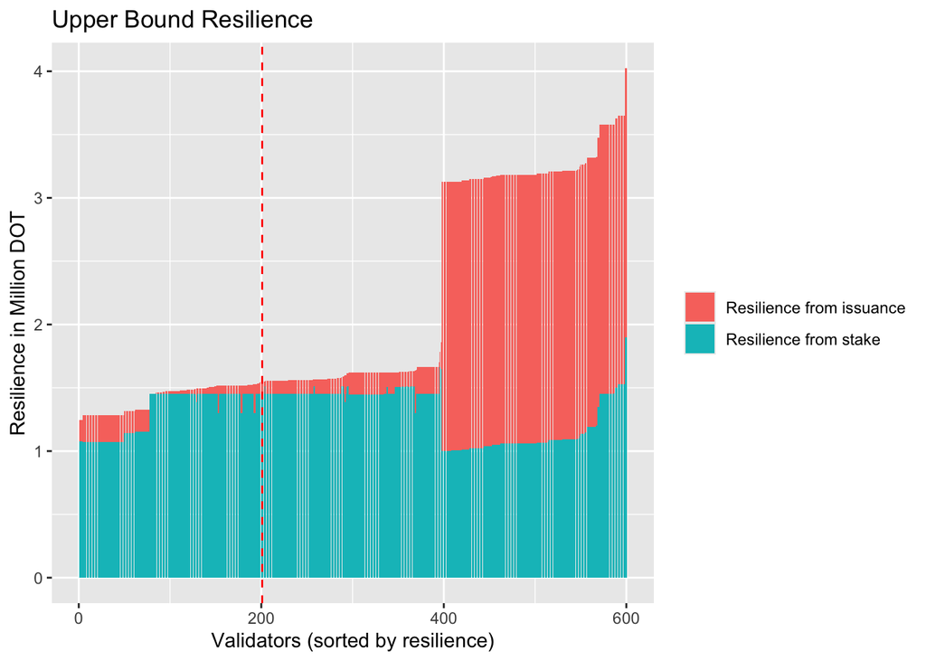

The attack adds up to 285,321,442 DOT (1,141,285,767 in fiat at 4 USD/DOT).

### Scenario B: Lower Bound

In contrast to the previous scenario, we assume an adversary that tries to bribe existing (and active) validators into colluding on an attack on consensus. In that situation, both the adversary and the validators only care about their self-stake getting slashed (or devalued) and the future rewards they are missing out. One realistic way that this could happen is through other *bridged* ecosystems (see the thought-experiment below). The following graph illustrates the economic security in that situation:

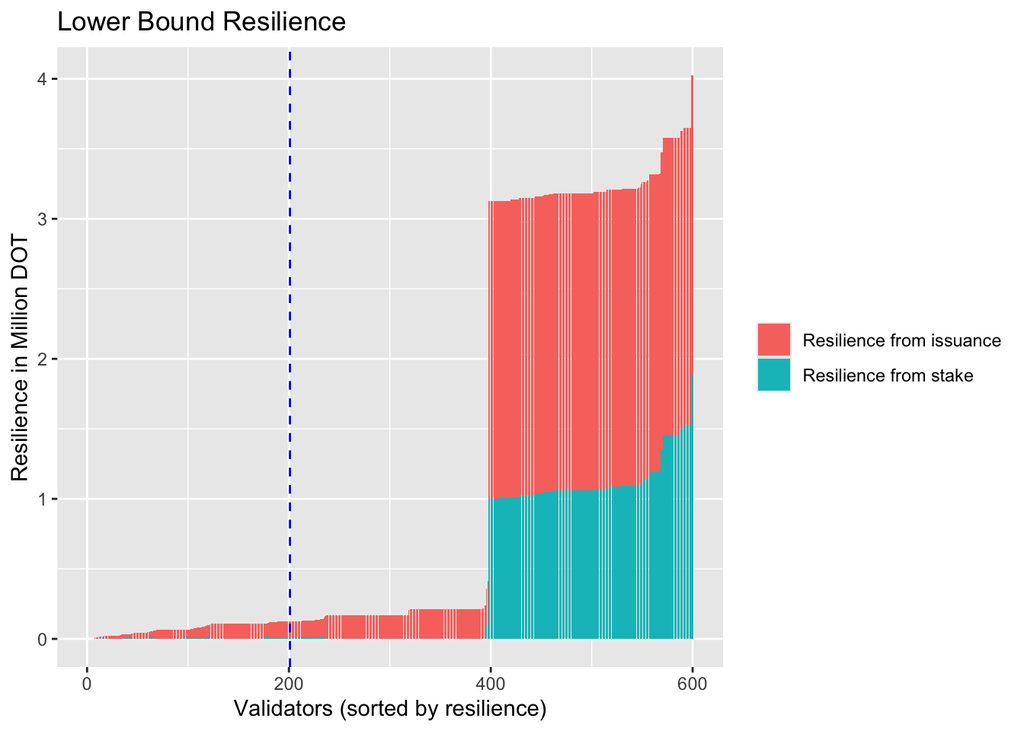

The attack costs 14,716,210 DOT (58,864,839 in fiat at 4 USD/DOT).

### Notes:

There are many things that influence an actual attack in reality. Some of them make the attack more costly, while other things make it cheaper. A few reasons an attack could be harder in reality are:

- Obtaining the necessary liquidity in Scenario A might have significant impact on the price and would increase the cost of such an attack. Certainly, building this attack would require a long time.
- For many validators their reputation has considerable value. That means, it is not enough to offset the costs of self-stake and future income with a bribe, instead would require a considerable premium. It is impossible to quantify that amount per validator or as a whole.

There are, however, reasons why the attack could also be cheaper in reality:

- A very realistic way to profit from such an attack would be to go short (with leverage) on DOT. Since stalling finality would most definitively negatively impact the market.
- There might be direct economic benefit of an attack, e.g., by moving sovereign assets (such as stable coins or assets not related to the Polkadot ecosystem), **if** the malicious entity can finalize malicious state transitions (i.e., obtains control of more than 1/3N+1).

### Key Metric: Lower Bound

If we consider the impact of certain policy changes, we should always consider how it affects the lower bound, as this counts as “worst-case” situation. We could even argue that the distance between the lower bound and upper bound collapses by employing a bit of game-theoretic thinking. To see that, we can employ a little **thought-experiment**. Assume an adversarial chain publicly announcing a bounty that just edges above the lower bound. The rules say that all validators that break consensus (at some block height in the future) receives an equal share of the bounty after proving to be part of the attack.

At that moment, all validators would be tempted to defect, and the situation turns into a coordination game with two (Nash) Equilibria: either everyone stays honest (i.e., the bounty is not high enough), or all defect. The reason is that it has very little value to remain honest, if 1/3N+1 of other validators defect, because consensus would fail and all value would be wiped. Importantly, without going into too much detail, the concept of a NE does not offer a reliable way to identify which strategies are actually being played by the actors (particularly if there are multiple equilibria). We could be more sophisticated and extend the analysis by modelling beliefs (and beliefs about beliefs) but this is mostly driven by the assumptions we employ. The important take-away is that if at least 1/3N+1 of validators could reasonably assume that 1/3N+1 will defect, and this becomes economical once the bounty is equal to the lower bound amount, the situation is critical. In that case, it is better to participate in the attack (even for a tiny payoff). In other words, offering the minimum amount to bribe 1/3N+1 might, depending on the believes of the validators, turn all validators to defect.

There are a few additional and dangerous implications:

1. This attack could entirely be coordinated publicly. There’s no need for hidden communication. The bounty could publicly be announced and validators individually make their choice (but will probably heavily try to find out whether a necessary 1/3N+1 will be found).
2. It might be possible to structure the claim of the reward trustlessly through some pre-funded smart contract that accepts a cryptographic proof of participation in the attack.
3. All announcements before the attack date from validators must be considered cheap talk, especially if they announce to not participate in the attack. Further, the fact that potentially more than 1/3N+1 of validators will defect could dangerously dilute individual responsibilities (“We knew that without us more than 1/3N+1 of other validators will defect, so the only reason we also defected was to get at least some payout”).
4. The public bounty could be configured to start at the lower bound and gradually increase to capture the necessary premium. If there is enough capital, the attack sooner or later will succeed (at minimum costs for the adversarial chain).

It lies in the nature of this bound that it is impossible to say “this amount of economic resilience is enough” versus “this amount signals imminent risk”, because it solely depends on the budget of the adversary. The naive, yet correct, approach is that more is better.

# Part II: The impact of a drastic issuance reduction on security

As we’ve seen above, the economic resilience of Polkadot is composed both of the self-stake of a validator and the expected future income from issuance. We can see that the resilience of the lower third (+1) of validators, those that are critical for security, are disproportionately driven by issuance rewards. That means, cutting issuance drastically translates almost proportionally decreasing the overall network security.

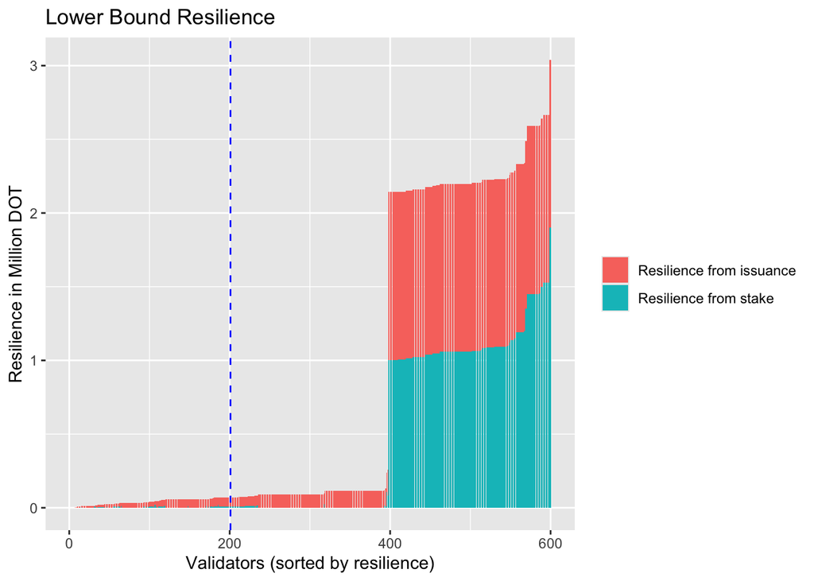

The total security reduces to 8,180,185 DOT (32,720,739 in fiat at 4 USD/DOT).

This appears to be a **dangerous** approach and we should make sure that a drastic reduction of issuance does not translate into lower security of the network. The third part of the report discusses potential additional policies to combine the goal of reducing issuance and keeping the network secure.

# Part III: Towards Sustainability & Security

After gaining a clearer understanding of how Polkadot derives its economic security in the current system, we can now explore practical options for moving forward.

### Note

**This should not be seen as a recommendation, but rather as a “necessary adjustment” if the consensus of the community is to drastically reduce issuance.**

Several key metrics come into play when evaluating these paths, including the economic security, issuance, nominator return, and the necessary revenue to offset issuance. Additionally, there has been growing interest in establishing a hard cap on the total DOT supply. The scenarios presented below illustrate possible adjustments that can be implemented using existing mechanisms. Importantly, to improve the security of the system, we aim to increase the lower bound despite significantly reducing the costs of the staking system.

### Goals

There are a lot of degrees of freedom of which economic policies to implement and with which parameters. Therefore, it is reasonable to state some goals and restrictions that need to be met by every potential mechanism.

- The lower bound of economic security must not be reduced. On the contrary, we seek policies to increase the security (as it appears to be rather low at the moment).
- Since most savings will come from reducing staker rewards, nominator APY must not be negative.
- The Treasury income stream is cut similarly as the staker rewards.

In general, we are aiming to set up Polkadot to be more balanced between the issuance of new tokens and the revenue it accrues. Importantly, the primary revenue sources are **coretime burns** ([RFC0010](https://polkadot-fellows.github.io/RFCs/approved/0010-burn-coretime-revenue.html)) and **transaction fee burns** ([RFC0146](https://polkadot-fellows.github.io/RFCs/approved/0146-deflationary-fee-proposal.html)). While actual revenue levels are uncertain and depend on network activity, we can estimate what monthly cost per core (assuming 150 cores) would be required to **fully offset issuance-driven token issuance**.

It’s important to note that fully neutralizing issuance is not strictly necessary, especially in a growing network where value accrual may outpace token dilution. However, working towards a more sustainable equation between issuance and deflation seems reasonable.

### Policy 1: Minimum Commission & Self-Stake

As discussed in Part II of the report, we have two direct levers on the economic resilience that is enforceable on a protocol level. The first, is to impose a minimum commission to upkeep validator rewards, and the second is to require a minimum self-stake of validators. The former upholds the value of the (discounted) future income. The latter requires validators to (potentially) increase their investment into the future of the network and commit more skin-in-the-game.

### Policy 2: Reduce Issuance

In the nature of this discussion, a reduction of the newly minted tokens will reduce the issuance. Importantly, the issuance in the current model is split by **staker-rewards** (279,439 DOT per day) and **treasury income** (49,313 DOT per day). issuance can be reduced by changing one or both of these issuance sources.

### Policy 3: Remove Nominator Slashing & Unbonding Duration

Under the current system, nominators receive the majority of staking rewards. As we have seen in the section above, the lower bound of economic security arguably does not depend on the nominator’s stake directly and therefore, these rewards pose the most potential for savings. To offset for lower nominative yield, we can reduce the perceived risk and complexity of staking. To do that, we propose to **remove slashing for nominators**, effectively making their participation risk-free. Alongside this, we increase the potential liquidity of bonded tokens by **removing the unbonding period**, allowing nominators to exit without delay (note that we might need to restrict withdrawing during a the small time-window that NPoS uses to take a snapshot to elect validators).

Removing these frictions would simplify the staking experience and provide justification for the necessary cut in staking APY. Nominators are still employed by the network to filter through validators, assess their reliability and quality, and submit their nominations to the election algorithm.

### Policy 4: Reduction Schedule

If we implement a continous reduction schedule, depending on the configuration of the total issuance, the system converges towards an upper cap. In the absence of any dynamic minting procedure (incorporating the distance to the cap, influenced by token burns), we end up at some endogenously defined upper cap. If we want to implement specific caps (e.g., **π-billion DOT** or **e-billion DOT** (Euler’s number), we need to specify dynamic minting functions that make the issuance dynamic to fit to the expected issuance schedule. It needs to be dynamic, because we burn token of an unpredictable amount. In general, the minting rate in any period is a function of the remaining distance to the cap, typically decreasing over time as the cap is approached. This has a useful side effect: when DOT are burned, for example through coretime purchases or transaction fee burns, the total supply decreases. That, in turn, widens the gap to the cap, and therefore slightly increases the allowable minting rate in subsequent periods. **More details on these considerations are outside the scope of this report and should be properly designed by proposers of new models**.

## Models

The first model describes the status quo with the linearly decreasing issuance schedule as it is deployed right now. Model 1 uses the hard pressure model of Referendum 1710 without any additional policies. Model 2 again assumes the hard pressure model but applies Policy 1 to improve Polkadot’s economic resilience.

**Assumptions**: After enforcing a minimum commission and minimum self-stake on the current validator set, we assume that every validator already meeting the criteria would not change their settings.

## Comparative Statistics

The numbers are for the current state of the network (for Status-quo) and after the first reduction of issuance (in Model 1 & 2). Future reductions will naturally impact these variables.

Comparison of Economic Security & issuance Metrics Across Scenarios

| Scenario | issuance Total issuance pct | issuance issuance to Stakers pct | Economic Security Upper Bound M DOT | Economic Security Lower Bound M DOT | Economic Security Yearly Cost M DOT | Staking Nominator APY pct | Staking Real Nominator APY pct | Staking Implied Staking Rate pct | Target Revenue Cost Per Core Month k DOT |
| --- | --- | --- | --- | --- | --- | --- | --- | --- | --- |
| Status Quo | 7.47 | 6.35 | 285.3 | 14.7 | 120.0 | 12.32 | 4.85 | 48.53 | 66.7 |
| Hard Pressure (- policies) | 4.00 | 3.40 | 275.3 | 8.2 | 64.3 | 6.60 | 2.60 | 48.53 | 35.7 |
| Hard Pressure (+ policies) | 4.00 | 3.40 | 288.1 | 26.3 | 64.3 | 6.31 | 2.31 | 48.53 | 35.7 |

# Conclusion

This report offered a concept of the economic resilience of Polkadot and how to quantify it. As an important factor, the resilience both depends on the DOT at stake (and for the “worst-case” lower bound, the self-stake of validators) and the expected (discounted) future rewards that stem from issuance. We’ve seen that especially Polkadot draws the economic resilience for the 1/3N+1 validators at the lower bound mostly from issuance. That means, cutting issuance significantly almost proportionally translates into lowering that bound. If the community votes to go that path, we’ve proposed additional policies that can make sure that we keep the security up (and, in fact, increase it), while lowering issuance.